# Fleet Definitions for Georges Bank

Andy Beet

23 March, 2021

## Spatial Extent

Statistical areas are used to define the Georges Bank footprint for pulling the landings data by gear

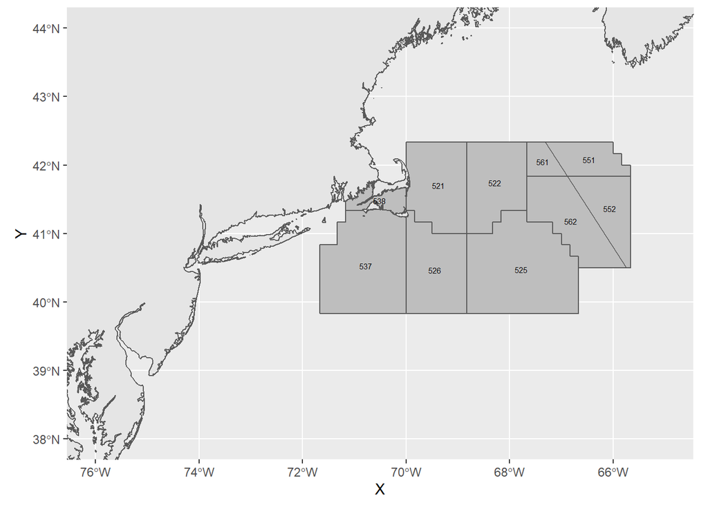

```r
crs <- 4326
# read in coastline and GB shape file
coast <- sf::st_read(here::here("gis", 'NES_LME_coast.shp'), quiet = T) %>%
  sf::st_transform(.,crs=crs)
GB_strata <- sf::st_read(here::here("gis","Statistical_Areas_2010.shp"),quiet=T) %>%
    sf::st_transform(.,crs=crs) %>%
  dplyr::filter(Id %in% c(521, 522, 523, 524, 525, 526, 538, 551, 552, 561, 562, 537) )
centroids <- sf::st_coordinates(sf::st_centroid(GB_strata))
GB_strata <- cbind(GB_strata,centroids)

#plot map
ggplot2::ggplot(data=coast) +
  ggplot2::geom_sf() +
  ggplot2::geom_sf(data=GB_strata,fill="grey") +
  ggplot2::geom_text(data=GB_strata,ggplot2::aes(x=X,y=Y,label=Id),size=2)    +
  ggplot2::coord_sf(xlim = c(-76,-65), ylim = c(38,44))
```

## Gear Types

There are a total of 52 unique NEGEAR2 codes (found in the cfdbs.gear table). However on Georges Bank not all of these fishing gears are used. A subset of 45 gear types are used. All gear codes:

| NEGEAR2 | GEARNM |
| --- | --- |
| -1 |  |
| -1 |  |
| -1 |  |
| -1 |  |
| -1 | SIDE TRAWL |
| -1 | STERN TRAWL |
| -1 | TRAWL, OTTER, MIDWATER |
| -1 | TRAWL, OTTER, MIDWATER |
| 01 | LONGLINE, BOTTOM |
| 02 | HANDLINE |

[output cut: 140 more lines]

## Aggregating Gear Types

Each gear type is designed to target particular species. Some gear types may catch predominantly one species (eg. Lobsters traps) where others may catch multiple species (bottom trawls). We aim to aggregate the gear types into fleets using similarities in the catch among the gear types. To achieve this we will adopt an agglomerative hierarchical, nearest neighbor clustering method (Manly (2017)) using euclidean distance as the measure of distance between groups. In this approach all gear types begin in separate groups. Groups that are similar (similar catch, defined by a distance measure) are then merged until at some distance all gear types belong to a single group. The variables used to determine the grouping are the species caught, measured by landings (in lbs)

Landings data, by gear type, are pulled from the database.

```r
channel <- dbutils::connect_to_database("server","id")
get_landings_by_data(channel,percentLanded=0.90,area=c(cfdbs::EPUs$data[["GB"]],537),outDir=here::here("data"))
```

The resulting data are then formatted as a data frame (or matrix) where each gear type is represented in a row and each species in a column. Each cell being the landings of the species by the gear type. Note: There will be many zeros in the data frame representing gear types that do not catch a particular species.

The variables are often standardized so that all of the variables are equally important in determining distances. We standardize each variable to have zero mean and unit variance. At this point pairwise distances between all gear types are calculated using the Euclidean distance function

$$d_{i,j} = \left( \sum_{k=1}^p(x_{i,k}-x_{j,k})^2 \right) ^{1/2}$$
where $x_{i,k}$ is the landings of species $k$ by gear type $i$ and $x_{j,k}$ is the landings of species $k$ by gear type $j$. $d_{i,j}$ is the measure of distance between gear type $i$ and $j$

A dendrogram is then formed using the agglomerative hierarchical process. This process is carried out using the statistical package `cluster` (Maechler et al. (2021)) in R.

### Approach: Use all gear types

For each gear type the landings of each species are aggregated over time and then ordered from the most abundant to least abundant. To reduce the number of variables (species) in the analysis we only use species which comprise 90% of the total landings for each gear type.

(Figure 1) shows the result of this approach. Initial inspection indicates further “cleaning” of the data is required.

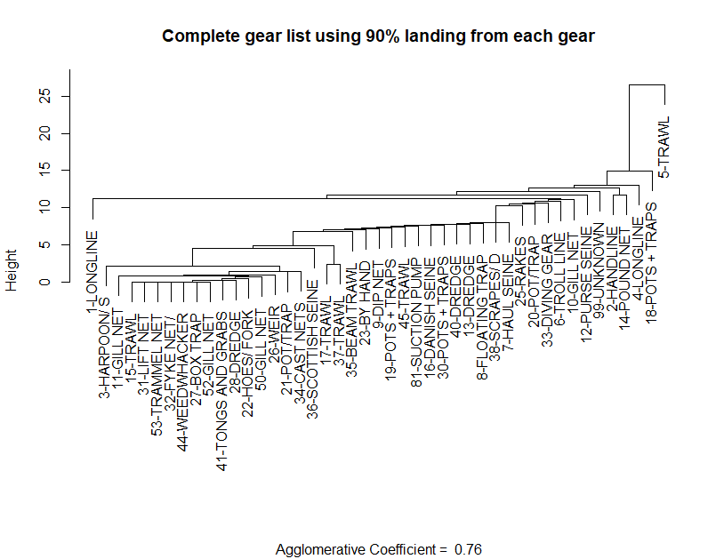

Figure 1: The dendrogram obtained from a nearest-neighbor, hierarchical cluster analysis on all gear types used in the Georges Bank Ecological Production unit as defined by statistical areas

```r
clusterObj <- cluster_analysis_all_gears()
plot(clusterObj,ask=T,which.plots=2,main="Complete gear list using 90% landing from each gear",xlab="")
```

### Approach: Use gears responsible for most landings

Total landings, aggregated over time, are ordered by gear type. The gear types that contribute to 99% of total landings are selected and used in the cluster analysis

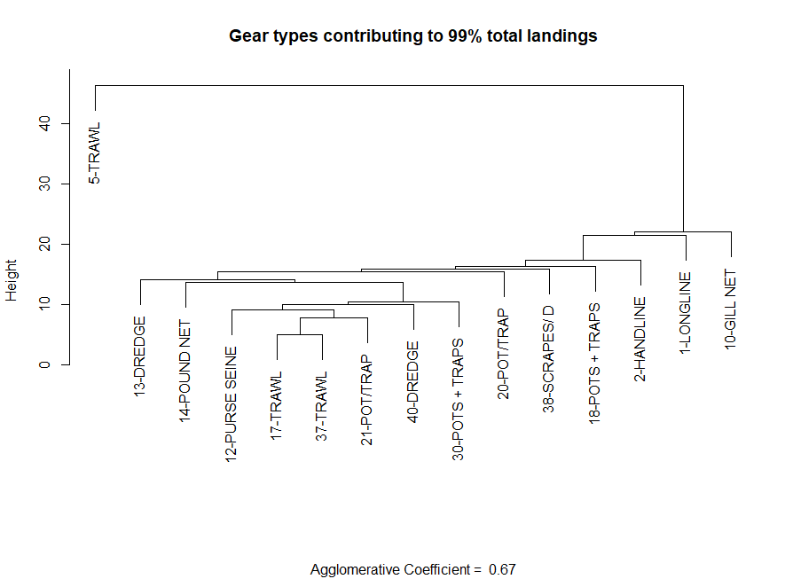

Figure 2: The dendrogram obtained from a nearest-neighbor, hierarchical cluster analysis on a subset of gear types in the Georges Bank Ecological Production unit as defined by statistical areas. Gear types were selected based on their contribution to 99% of landings

```r
clusterObj <- cluster_analysis_filter_gears(filterByLandings=.99)
plot(clusterObj$top,ask=T,which.plots=2,main="Gear types contributing to 99% of total landings",xlab="")
```

### Species landings by gear

Time series of species caught by each gear type. To reduce the number of panels in each figure, species caught < 30% of the time are not displayed. For example reporting of landings started in 1964 (56 years ago). So any species that have reported landings in fewer that 17 years are not displayed.

```r
for (gear in clusteObj$topGears) {
  explore_landings_by_gear(channel,data=gearData$data,gearCode=gear,filterYrs=0.30,saveToFile=T)
}
```

#### 01

```
## # A tibble: 1 x 2
##   NEGEAR2 GEARNM
##   <chr>   <chr>
## 1 01      LONGLINE, BOTTOM
```

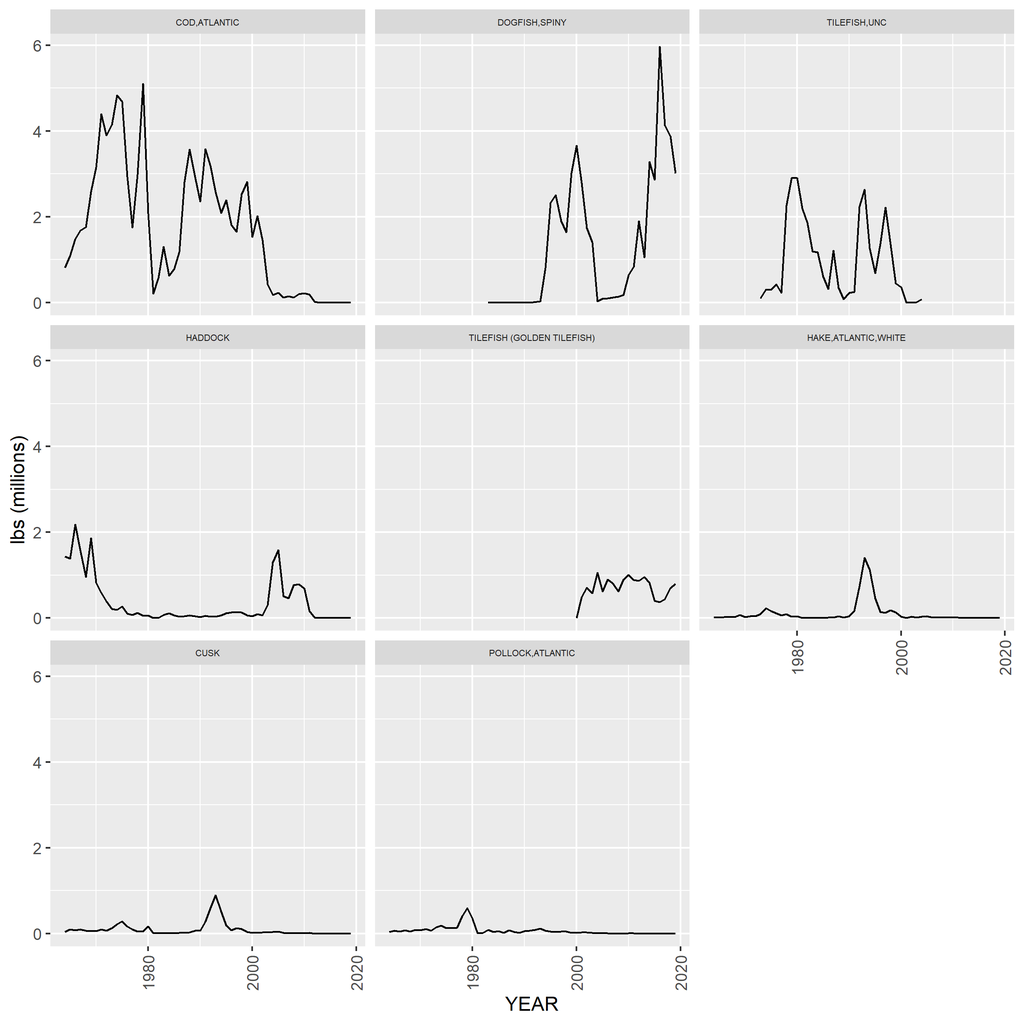

#### 02

```
## # A tibble: 2 x 2
##   NEGEAR2 GEARNM
##   <chr>   <chr>
## 1 02      HANDLINE
## 2 02      HANDLINE,AUTO JIG
```

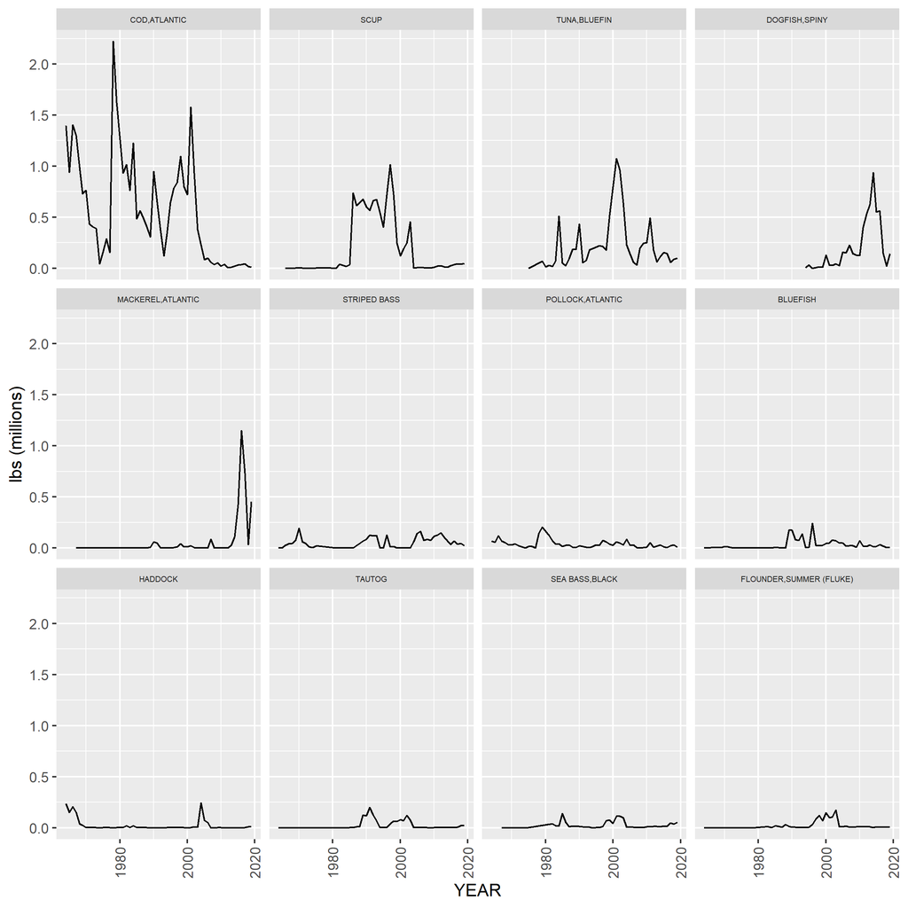

#### 05

```
## # A tibble: 10 x 2
##    NEGEAR2 GEARNM
##    <chr>   <chr>
##  1 05      TRAWL,OTTER,BOTTOM,FISH
##  2 05      TRAWL,OTTER,BOTTOM,CRAB
##  3 05      TRAWL,OTTER,BOTTOM,SCALLOP
##  4 05      TRAWL,OTTER,BOTTOM,TWIN
##  5 05      TRAWL,OTTER,BOTTOM,RUHLE
##  6 05      TRAWL,OTTER,BOTTOM,LOBSTER
##  7 05      TRAWL,OTTER,BOTTOM PAIRED
##  8 05      TRAWL,OTTER,BOTTOM,HADDOCK SEPARATOR
##  9 05      TRAWL,OTTER,BOTTOM,SHRIMP
## 10 05      TRAWL,OTTER,BOTTOM,OTHER/NK SPECIES
```

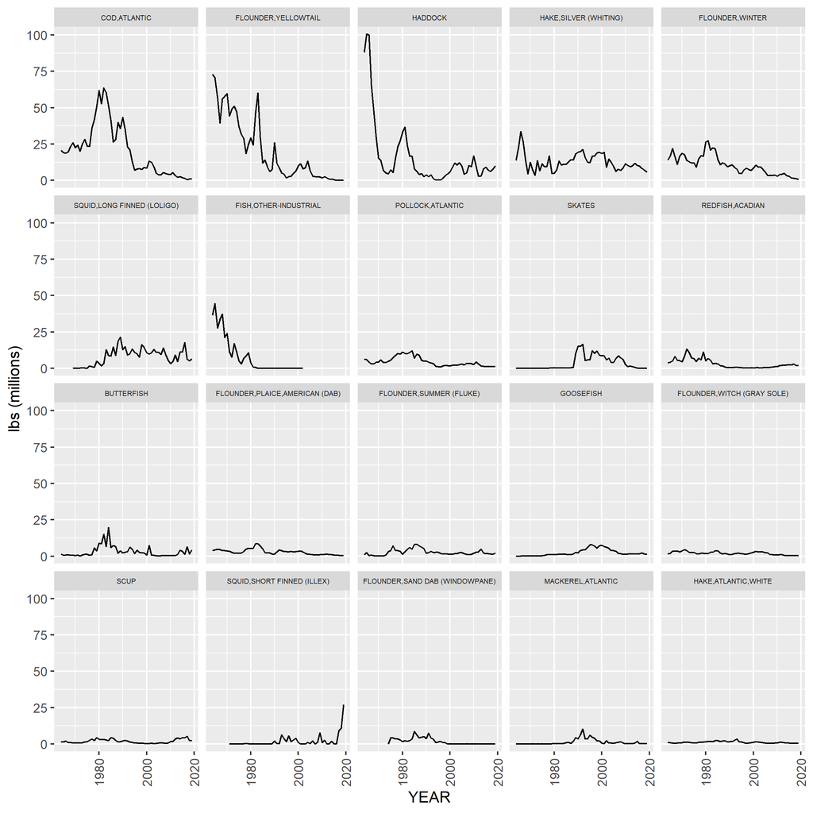

#### 10

```
## # A tibble: 6 x 2
##   NEGEAR2 GEARNM
##   <chr>   <chr>
## 1 10      GILL NET, FIXED OR ANCHORED,SINK, OTHER/NK SPECIES
## 2 10      GILL NET,SET /STAKE, SEA BASS
## 3 10      GILL NET,STAKE,OTHER
## 4 10      GILL NET,SET, SALMON
## 5 10      GILL NET,SET, CRAB
## 6 10      GILL NET,ANCHORED-FLOATING, FISH
```

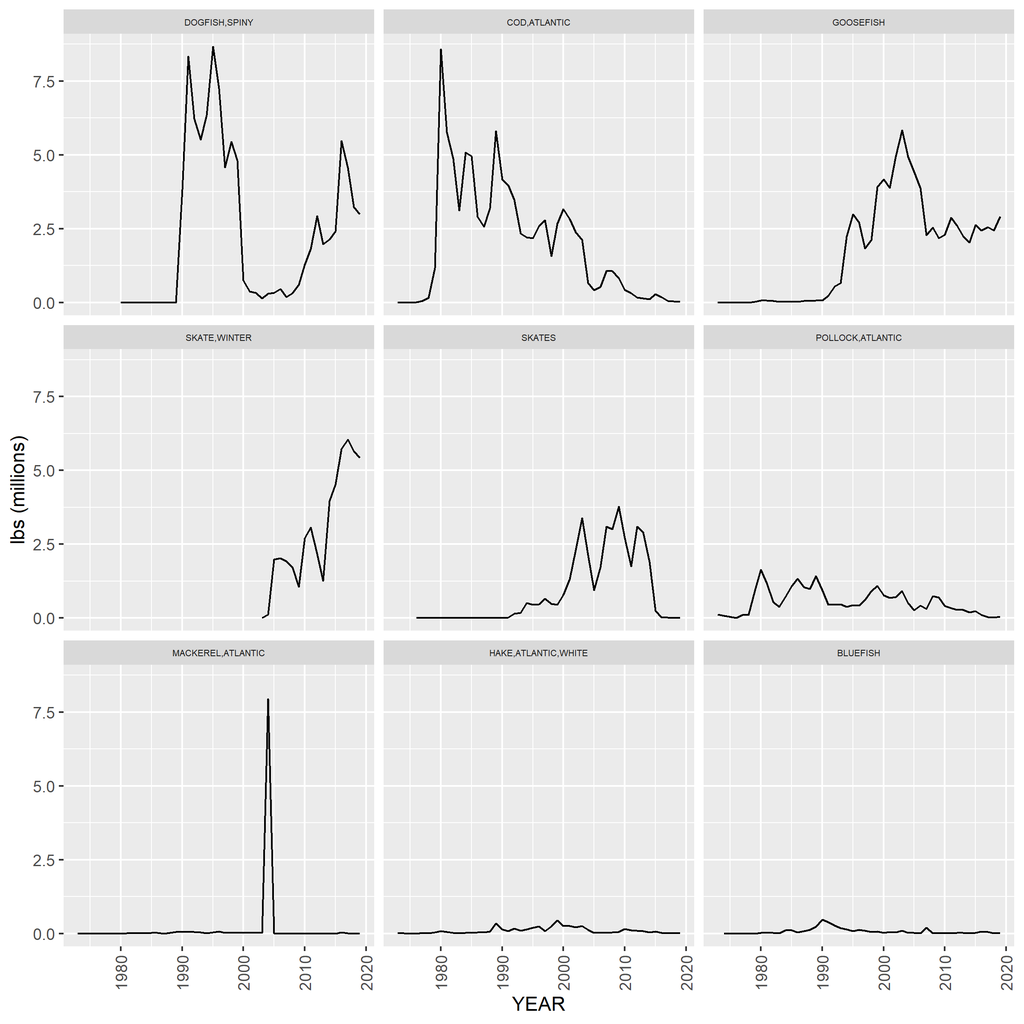

#### 12

```
## # A tibble: 5 x 2
##   NEGEAR2 GEARNM
##   <chr>   <chr>
## 1 12      PURSE SEINE, OTHER/NK SPECIES
## 2 12      PURSE SEINE, HERRING
## 3 12      PURSE SEINE, MACKEREL
## 4 12      PURSE SEINE, MENHADEN
## 5 12      PURSE SEINE, TUNA
```

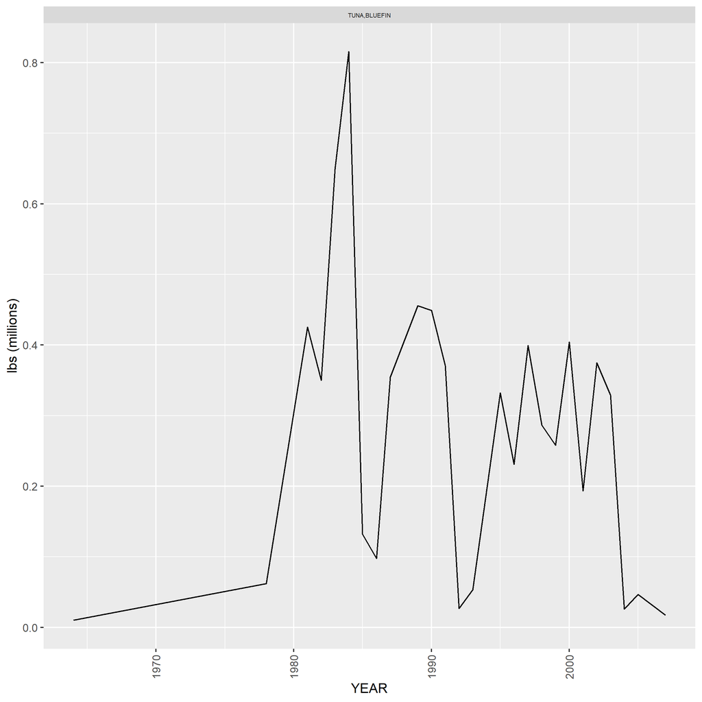

#### 13

```
## # A tibble: 2 x 2
##   NEGEAR2 GEARNM
##   <chr>   <chr>
## 1 13      DREDGE, SCALLOP,BAY
## 2 13      DREDGE, SCALLOP,SEA
```

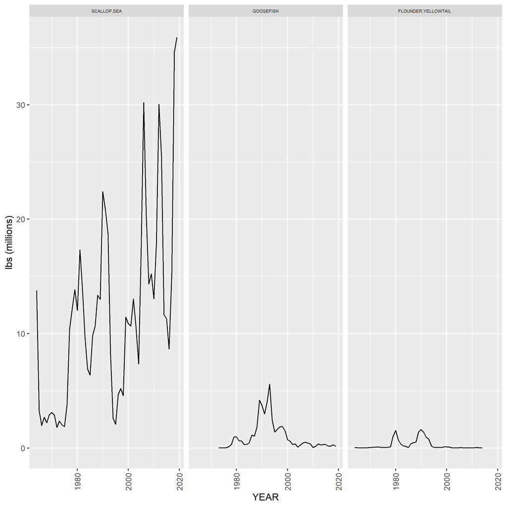

#### 14

```
## # A tibble: 4 x 2
##   NEGEAR2 GEARNM
##   <chr>   <chr>
## 1 14      POUND NET, OTHER/NK SPECIES
## 2 14      POUND NET, CRAB
## 3 14      POUND NET, FISH
## 4 14      POUND NET, HORSESHOE CRAB
```

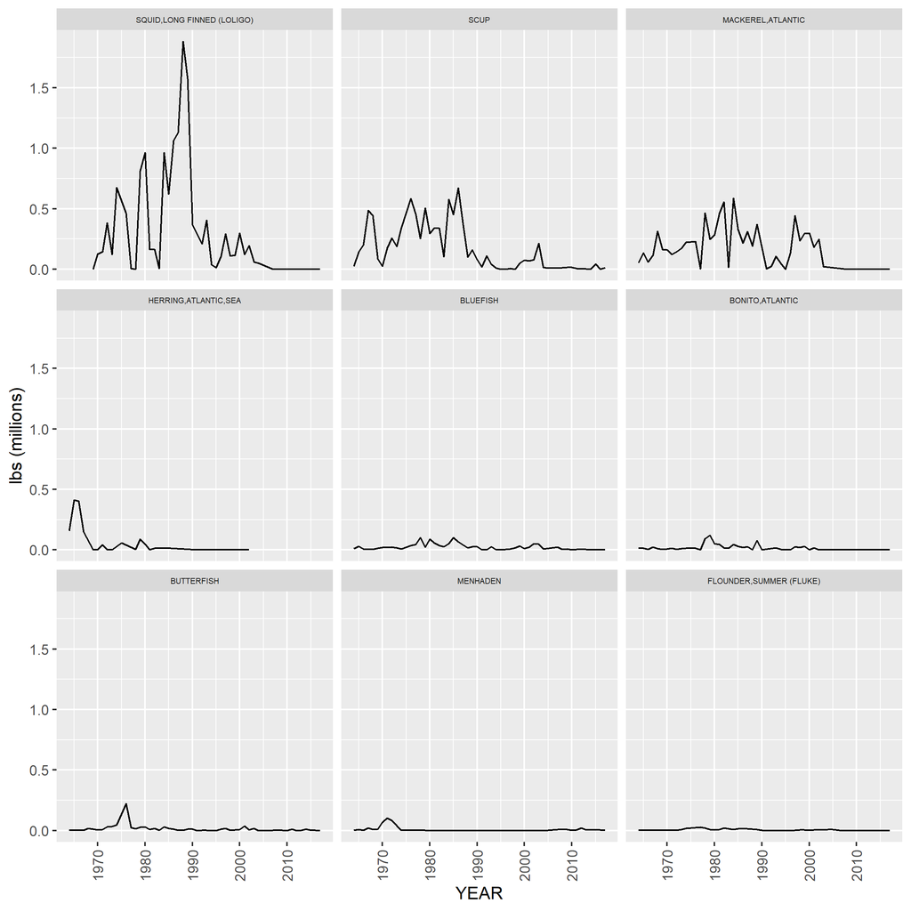

#### 17

```
## # A tibble: 1 x 2
##   NEGEAR2 GEARNM
##   <chr>   <chr>
## 1 17      TRAWL,OTTER,MIDWATER PAIRED
```

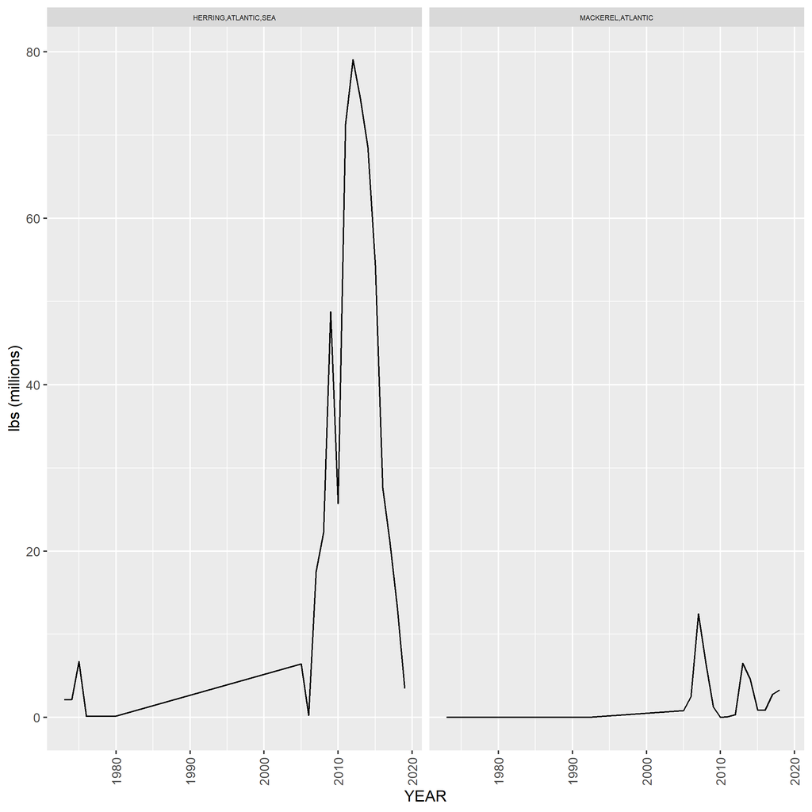

#### 18

```
## # A tibble: 7 x 2
##   NEGEAR2 GEARNM
##   <chr>   <chr>
## 1 18      POTS + TRAPS,OTHER/NK SPECIES
## 2 18      POTS + TRAPS,FISH
## 3 18      POTS + TRAPS,EEL
## 4 18      POTS + TRAPS,CONCH
## 5 18      POTS + TRAPS,OCTOPUS
## 6 18      POTS + TRAPS,TURTLE
## 7 18      POTS + TRAPS, HAGFISH
```

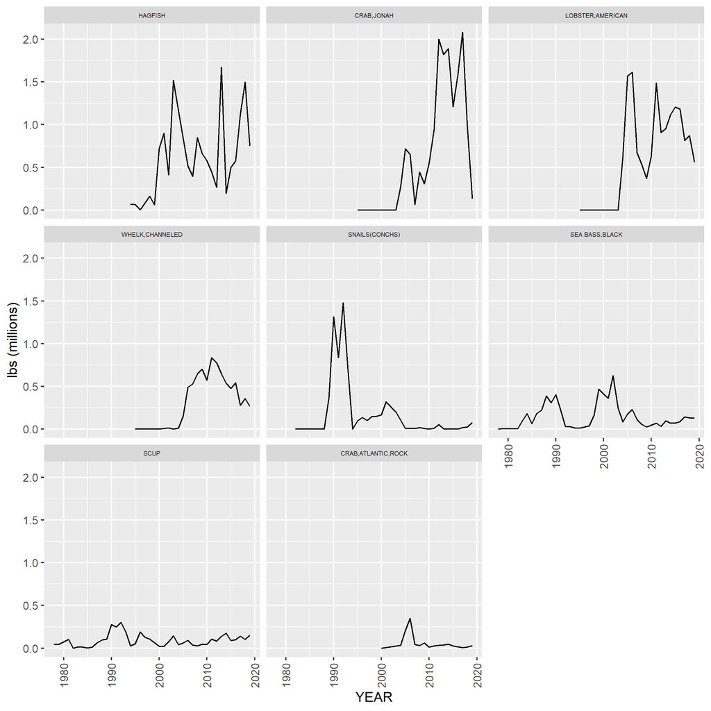

#### 20

```
## # A tibble: 8 x 2
##   NEGEAR2 GEARNM
##   <chr>   <chr>
## 1 20      POT/TRAP, LOBSTER OFFSH NK
## 2 20      POT/TRAP, LOBSTER OFFSH WOOD
## 3 20      POT/TRAP, LOBSTER OFFSH WIRE
## 4 20      POT/TRAP, LOBSTER OFFSH WD/WR
## 5 20      POT/TRAP, LOBSTER OFFSH WD/NET
## 6 20      POT/TRAP, LOBSTER OFFSH WR/NET
## 7 20      POT/TRAP, LOBSTER OFFSH PLASTIC
## 8 20      POT/TRAP, LOBSTER OFFSH CONICAL
```

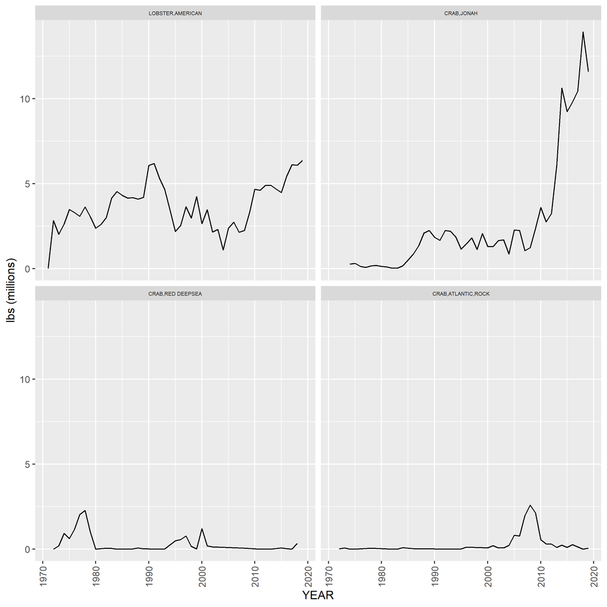

#### 21

```
## # A tibble: 8 x 2
##   NEGEAR2 GEARNM
##   <chr>   <chr>
## 1 21      POT/TRAP, LOBSTER INSH NK
## 2 21      POT/TRAP, LOBSTER INSH WOOD
## 3 21      POT/TRAP, LOBSTER INSH WIRE
## 4 21      POT/TRAP, LOBSTER INSH WD/WR
## 5 21      POT/TRAP, LOBSTER INSH WD/NET
## 6 21      POT/TRAP, LOBSTER INSH WR/NET
## 7 21      POT/TRAP, LOBSTER INSH PLASTIC
## 8 21      POT/TRAP, LOBSTER INSH CONICAL
```

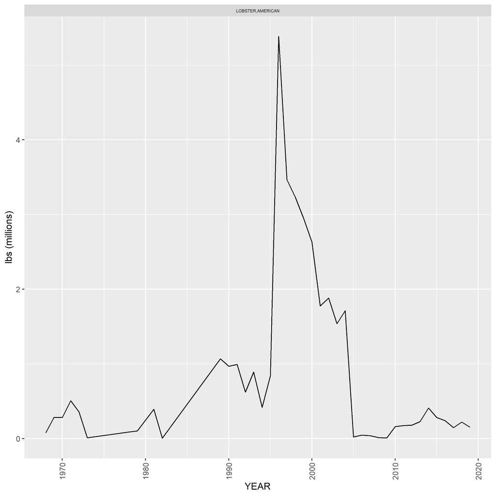

#### 30

```
## # A tibble: 2 x 2
##   NEGEAR2 GEARNM
##   <chr>   <chr>
## 1 30      POTS + TRAPS,CRAB OTHER
## 2 30      POTS + TRAPS,BLUE CRAB
```

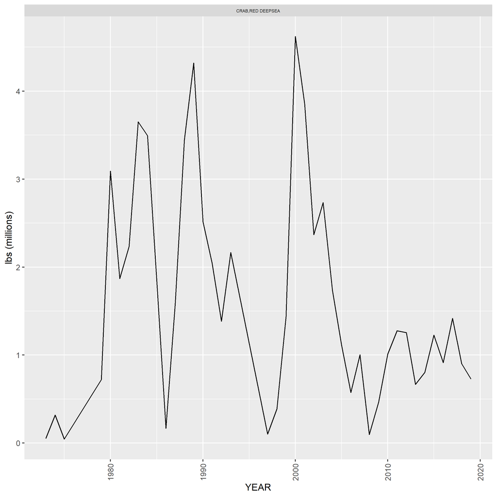

#### 37

```
## # A tibble: 1 x 2
##   NEGEAR2 GEARNM
##   <chr>   <chr>
## 1 37      TRAWL,OTTER,MIDWATER
```

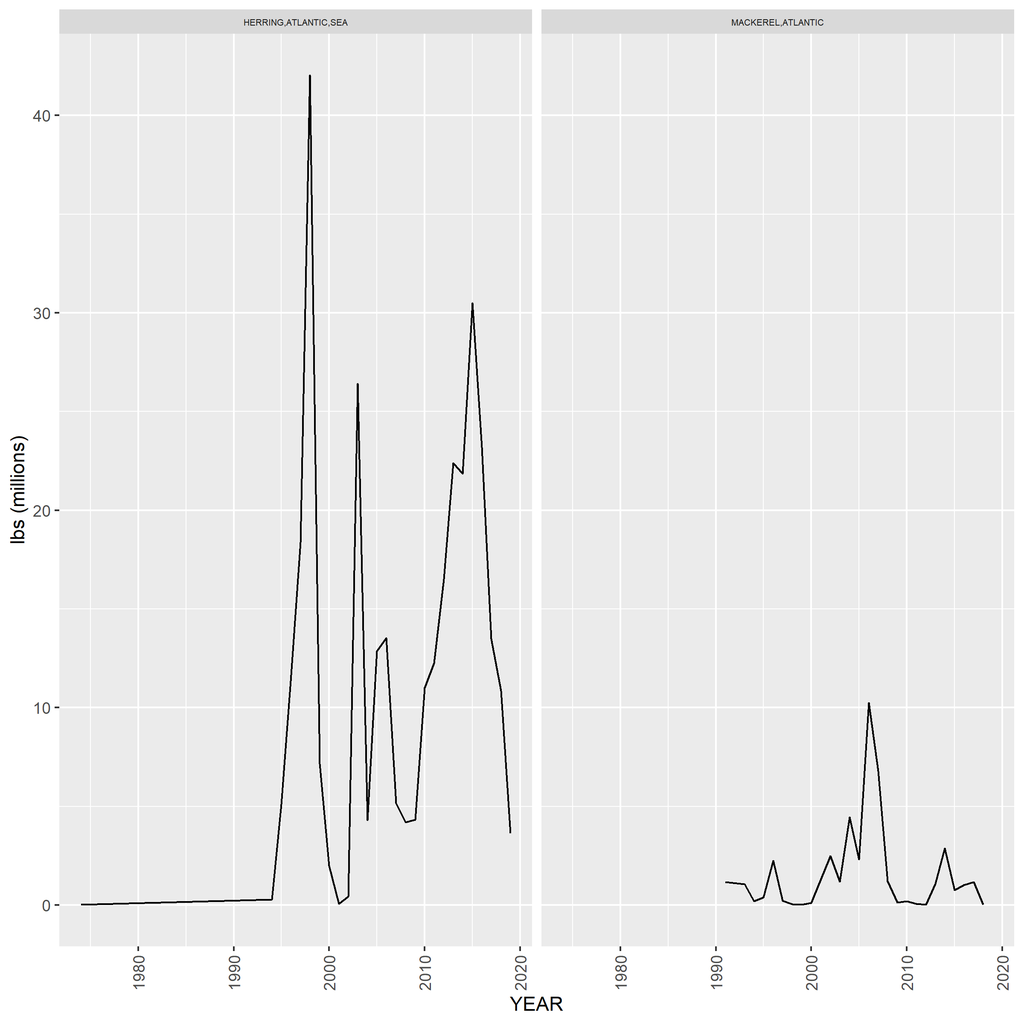

#### 38

```
## # A tibble: 8 x 2
##   NEGEAR2 GEARNM
##   <chr>   <chr>
## 1 38      SCRAPES
## 2 38      DREDGE, OTHER/NK SPECIES
## 3 38      DREDGE, CLAM
## 4 38      DREDGE, CRAB
## 5 38      DREDGE, CONCH
## 6 38      DREDGE, MUSSEL
## 7 38      DREDGE, CLAM, HYDRAULIC
## 8 38      DREDGE, URCHIN
```

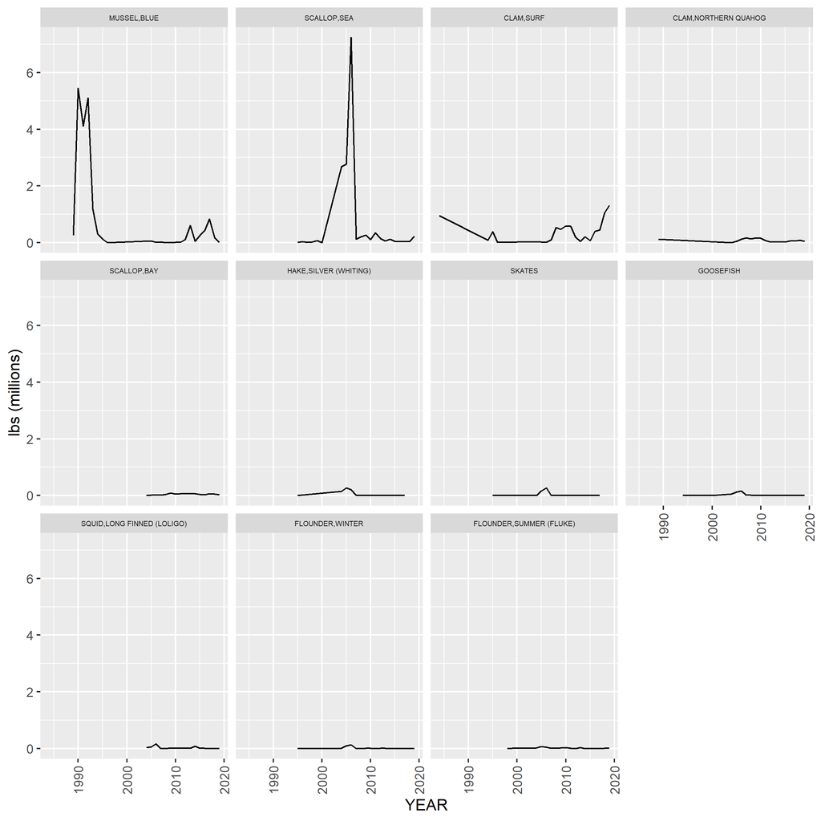

#### 40

```
## # A tibble: 1 x 2
##   NEGEAR2 GEARNM
##   <chr>   <chr>
## 1 40      DREDGE, SURF CLAM + OCEAN QUAHO
```

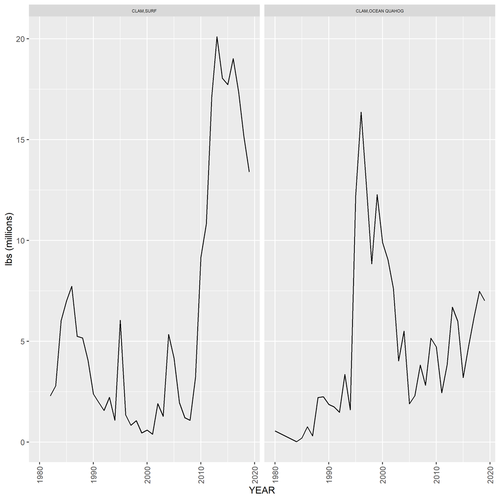

### Gears that make up < 1% landings

The remaining gears (not contributing to 99% of the landings) were used in a cluster analysis to determine how similar these gears are to each other, since 100% of landings should be accounted for.

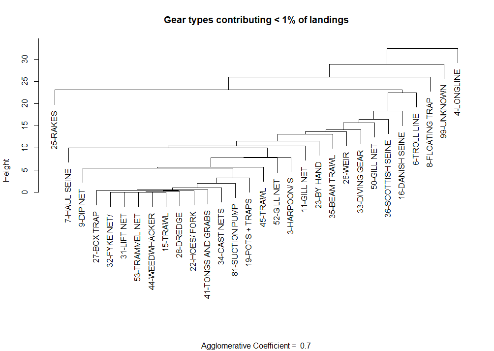

Figure 3: The dendrogram obtained from a nearest-neighbor, hierarchical cluster analysis on a subset of gear types in the Georges Bank Ecological Production unit as defined by statistical areas. Gear types were selected based on not contributing to top 99% of landings

```r
plot(clusterObj$bottom,ask=T,which.plots=2,main="Gear types contributing < 1% of total landings",xlab="")
```

### Approach: Select gear types that catch species of interest

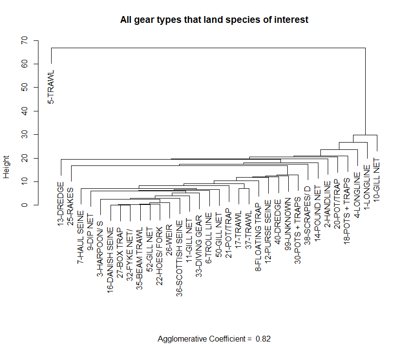

Figure 4: The dendrogram obtained from a nearest-neighbor, hierarchical cluster analysis on a subset of gear types in the Georges Bank Ecological Production unit as defined by statistical areas. All gear types that landed species of interest were selected

```r
focalSpecies <- readRDS(here::here("data","focalspecies.rds"))
clusterObj <- cluster_by_focal_species(focalSpecies)
plot(clusterObj,ask=T,which.plots=2,main="All gear types that land species of interest",xlab="")
```

## Decision

This exploratory study resulted in the following designation of [Fleets](https://noaa-edab.github.io/ms-keyrun/GBFleetDecisions.html)

## References

Maechler, M., Rousseeuw, P., Struyf, A., Hubert, M., & Hornik, K. (2021). *Cluster: Cluster analysis basics and extensions*. https://CRAN.R-project.org/package=cluster

R package version 2.1.1 — For new features, see the ’Changelog’ file (in the package source)

Manly, B. F. J. (2017). *Multivariate statistical methods* (Fourth edition). Chapman & Hall.